# Risk Factor Analysis

## Outcome Variable

**Outcome Variable:** whz

## Predictor Variables

**Intervention Variable:** predfeed36

**Adjustment Set:**

- arm
- sex
- month
- brthmon
- W_mage
- meducyrs
- feducyrs
- hhwealth_quart
- hfoodsec
- W_mhtcm
- W_mwtkg
- W_mbmi
- vagbrth
- W_gagebrth
- W_birthwt
- W_birthlen
- W_nrooms
- W_nchldlt5
- W_parity
- impfloor
- impsan
- safeh20
- delta_W_mage
- delta_meducyrs
- delta_feducyrs
- delta_hhwealth_quart
- delta_hfoodsec
- delta_W_mhtcm
- delta_W_mwtkg
- delta_W_mbmi
- delta_vagbrth
- delta_W_gagebrth
- delta_W_birthwt
- delta_W_birthlen
- delta_W_nrooms
- delta_W_nchldlt5
- delta_W_parity
- delta_impfloor
- delta_impsan
- delta_safeh20

## Stratifying Variables

The analysis was stratified on these variable(s):

- agecat
- studyid
- country

## Data Summary

| agecat | studyid | country | predfeed36 | n_cell | n | outcome_variable |
| --- | --- | --- | --- | --- | --- | --- |
| Birth | EE | PAKISTAN | 1 | 2 | 6 | whz |
| Birth | EE | PAKISTAN | 0 | 4 | 6 | whz |
| Birth | GMS-Nepal | NEPAL | 1 | 396 | 491 | whz |
| Birth | GMS-Nepal | NEPAL | 0 | 95 | 491 | whz |
| Birth | JiVitA-3 | BANGLADESH | 1 | 6746 | 8619 | whz |
| Birth | JiVitA-3 | BANGLADESH | 0 | 1873 | 8619 | whz |
| Birth | JiVitA-4 | BANGLADESH | 1 | 1714 | 2128 | whz |
| Birth | JiVitA-4 | BANGLADESH | 0 | 414 | 2128 | whz |
| Birth | MAL-ED | BANGLADESH | 1 | 69 | 208 | whz |
| Birth | MAL-ED | BANGLADESH | 0 | 139 | 208 | whz |
| Birth | MAL-ED | BRAZIL | 1 | 7 | 62 | whz |
| Birth | MAL-ED | BRAZIL | 0 | 55 | 62 | whz |
| Birth | MAL-ED | INDIA | 1 | 4 | 40 | whz |
| Birth | MAL-ED | INDIA | 0 | 36 | 40 | whz |
| Birth | MAL-ED | NEPAL | 1 | 1 | 25 | whz |
| Birth | MAL-ED | NEPAL | 0 | 24 | 25 | whz |
| Birth | MAL-ED | PERU | 1 | 57 | 218 | whz |
| Birth | MAL-ED | PERU | 0 | 161 | 218 | whz |
| Birth | MAL-ED | SOUTH AFRICA | 1 | 2 | 104 | whz |
| Birth | MAL-ED | SOUTH AFRICA | 0 | 102 | 104 | whz |
| Birth | MAL-ED | TANZANIA, UNITED REPUBLIC OF | 1 | 0 | 111 | whz |
| Birth | MAL-ED | TANZANIA, UNITED REPUBLIC OF | 0 | 111 | 111 | whz |
| 6 months | EE | PAKISTAN | 1 | 4 | 9 | whz |
| 6 months | EE | PAKISTAN | 0 | 5 | 9 | whz |
| 6 months | GMS-Nepal | NEPAL | 1 | 422 | 527 | whz |
| 6 months | GMS-Nepal | NEPAL | 0 | 105 | 527 | whz |
| 6 months | JiVitA-3 | BANGLADESH | 1 | 6576 | 8535 | whz |
| 6 months | JiVitA-3 | BANGLADESH | 0 | 1959 | 8535 | whz |
| 6 months | JiVitA-4 | BANGLADESH | 1 | 3252 | 4188 | whz |
| 6 months | JiVitA-4 | BANGLADESH | 0 | 936 | 4188 | whz |
| 6 months | LCNI-5 | MALAWI | 1 | 47 | 272 | whz |
| 6 months | LCNI-5 | MALAWI | 0 | 225 | 272 | whz |
| 6 months | MAL-ED | BANGLADESH | 1 | 81 | 240 | whz |
| 6 months | MAL-ED | BANGLADESH | 0 | 159 | 240 | whz |
| 6 months | MAL-ED | BRAZIL | 1 | 25 | 209 | whz |
| 6 months | MAL-ED | BRAZIL | 0 | 184 | 209 | whz |
| 6 months | MAL-ED | INDIA | 1 | 17 | 233 | whz |
| 6 months | MAL-ED | INDIA | 0 | 216 | 233 | whz |
| 6 months | MAL-ED | NEPAL | 1 | 8 | 235 | whz |
| 6 months | MAL-ED | NEPAL | 0 | 227 | 235 | whz |
| 6 months | MAL-ED | PERU | 1 | 72 | 272 | whz |
| 6 months | MAL-ED | PERU | 0 | 200 | 272 | whz |
| 6 months | MAL-ED | SOUTH AFRICA | 1 | 3 | 250 | whz |
| 6 months | MAL-ED | SOUTH AFRICA | 0 | 247 | 250 | whz |
| 6 months | MAL-ED | TANZANIA, UNITED REPUBLIC OF | 1 | 5 | 243 | whz |
| 6 months | MAL-ED | TANZANIA, UNITED REPUBLIC OF | 0 | 238 | 243 | whz |
| 6 months | SAS-FoodSuppl | INDIA | 1 | 0 | 168 | whz |
| 6 months | SAS-FoodSuppl | INDIA | 0 | 168 | 168 | whz |
| 24 months | EE | PAKISTAN | 1 | 0 | 3 | whz |
| 24 months | EE | PAKISTAN | 0 | 3 | 3 | whz |
| 24 months | GMS-Nepal | NEPAL | 1 | 362 | 445 | whz |
| 24 months | GMS-Nepal | NEPAL | 0 | 83 | 445 | whz |
| 24 months | JiVitA-3 | BANGLADESH | 1 | 3320 | 4317 | whz |
| 24 months | JiVitA-3 | BANGLADESH | 0 | 997 | 4317 | whz |
| 24 months | JiVitA-4 | BANGLADESH | 1 | 3144 | 4035 | whz |
| 24 months | JiVitA-4 | BANGLADESH | 0 | 891 | 4035 | whz |
| 24 months | LCNI-5 | MALAWI | 1 | 34 | 184 | whz |
| 24 months | LCNI-5 | MALAWI | 0 | 150 | 184 | whz |
| 24 months | MAL-ED | BANGLADESH | 1 | 69 | 212 | whz |
| 24 months | MAL-ED | BANGLADESH | 0 | 143 | 212 | whz |
| 24 months | MAL-ED | BRAZIL | 1 | 20 | 169 | whz |
| 24 months | MAL-ED | BRAZIL | 0 | 149 | 169 | whz |
| 24 months | MAL-ED | INDIA | 1 | 17 | 224 | whz |
| 24 months | MAL-ED | INDIA | 0 | 207 | 224 | whz |
| 24 months | MAL-ED | NEPAL | 1 | 8 | 227 | whz |
| 24 months | MAL-ED | NEPAL | 0 | 219 | 227 | whz |
| 24 months | MAL-ED | PERU | 1 | 53 | 201 | whz |
| 24 months | MAL-ED | PERU | 0 | 148 | 201 | whz |
| 24 months | MAL-ED | SOUTH AFRICA | 1 | 3 | 235 | whz |
| 24 months | MAL-ED | SOUTH AFRICA | 0 | 232 | 235 | whz |
| 24 months | MAL-ED | TANZANIA, UNITED REPUBLIC OF | 1 | 4 | 213 | whz |
| 24 months | MAL-ED | TANZANIA, UNITED REPUBLIC OF | 0 | 209 | 213 | whz |

The following strata were considered:

- agecat: 24 months, studyid: EE, country: PAKISTAN
- agecat: 24 months, studyid: GMS-Nepal, country: NEPAL
- agecat: 24 months, studyid: JiVitA-3, country: BANGLADESH
- agecat: 24 months, studyid: JiVitA-4, country: BANGLADESH
- agecat: 24 months, studyid: LCNI-5, country: MALAWI
- agecat: 24 months, studyid: MAL-ED, country: BANGLADESH
- agecat: 24 months, studyid: MAL-ED, country: BRAZIL
- agecat: 24 months, studyid: MAL-ED, country: INDIA
- agecat: 24 months, studyid: MAL-ED, country: NEPAL
- agecat: 24 months, studyid: MAL-ED, country: PERU
- agecat: 24 months, studyid: MAL-ED, country: SOUTH AFRICA
- agecat: 24 months, studyid: MAL-ED, country: TANZANIA, UNITED REPUBLIC OF
- agecat: 6 months, studyid: EE, country: PAKISTAN
- agecat: 6 months, studyid: GMS-Nepal, country: NEPAL
- agecat: 6 months, studyid: JiVitA-3, country: BANGLADESH
- agecat: 6 months, studyid: JiVitA-4, country: BANGLADESH
- agecat: 6 months, studyid: LCNI-5, country: MALAWI
- agecat: 6 months, studyid: MAL-ED, country: BANGLADESH
- agecat: 6 months, studyid: MAL-ED, country: BRAZIL
- agecat: 6 months, studyid: MAL-ED, country: INDIA
- agecat: 6 months, studyid: MAL-ED, country: NEPAL
- agecat: 6 months, studyid: MAL-ED, country: PERU
- agecat: 6 months, studyid: MAL-ED, country: SOUTH AFRICA
- agecat: 6 months, studyid: MAL-ED, country: TANZANIA, UNITED REPUBLIC OF
- agecat: 6 months, studyid: SAS-FoodSuppl, country: INDIA
- agecat: Birth, studyid: EE, country: PAKISTAN
- agecat: Birth, studyid: GMS-Nepal, country: NEPAL
- agecat: Birth, studyid: JiVitA-3, country: BANGLADESH
- agecat: Birth, studyid: JiVitA-4, country: BANGLADESH
- agecat: Birth, studyid: MAL-ED, country: BANGLADESH
- agecat: Birth, studyid: MAL-ED, country: BRAZIL
- agecat: Birth, studyid: MAL-ED, country: INDIA
- agecat: Birth, studyid: MAL-ED, country: NEPAL
- agecat: Birth, studyid: MAL-ED, country: PERU
- agecat: Birth, studyid: MAL-ED, country: SOUTH AFRICA
- agecat: Birth, studyid: MAL-ED, country: TANZANIA, UNITED REPUBLIC OF

### Dropped Strata

Some strata were dropped due to rare outcomes:

- agecat: Birth, studyid: EE, country: PAKISTAN
- agecat: Birth, studyid: MAL-ED, country: INDIA
- agecat: Birth, studyid: MAL-ED, country: NEPAL
- agecat: Birth, studyid: MAL-ED, country: SOUTH AFRICA
- agecat: Birth, studyid: MAL-ED, country: TANZANIA, UNITED REPUBLIC OF
- agecat: 6 months, studyid: EE, country: PAKISTAN
- agecat: 6 months, studyid: MAL-ED, country: SOUTH AFRICA
- agecat: 6 months, studyid: SAS-FoodSuppl, country: INDIA
- agecat: 24 months, studyid: EE, country: PAKISTAN
- agecat: 24 months, studyid: MAL-ED, country: SOUTH AFRICA
- agecat: 24 months, studyid: MAL-ED, country: TANZANIA, UNITED REPUBLIC OF

## Methods Detail

We’re interested in the causal parameters $E[Y_a]$ for all values of $a \in \mathcal{A}$. These parameters represent the mean outcome if, possibly contrary to fact, we intervened to set all units to have $A=a$. Under the randomization and positivity assumptions, these are identified by the statistical parameters $\psi_a=E_W[E_{Y|A,W}(Y|A=a,W)]$. In addition, we’re interested in the mean of $Y$, $E[Y]$ under no intervention (the observed mean). We will estimate these parameters by using SuperLearner to fit the relevant likelihood factors – $E_{Y|A,W}(Y|A=a,W)$ and $p(A=a|W)$, and then updating our likelihood fit using a joint TMLE.

For unadjusted analyses ($W=\{\}$), initial likelihoods were estimated using Lrnr_glm to estimate the simple $E(Y|A)$ and Lrnr_mean to estimate $p(A)$. For adjusted analyses, a small library containing Lrnr_glmnet, Lrnr_xgboost, and Lrnr_mean was used.

Having estimated these parameters, we will then use the delta method to estimate relative risks and attributable risks relative to a prespecified baseline level of $A$.

# Results Detail

## Results Plots

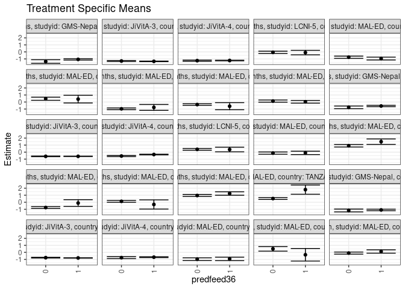

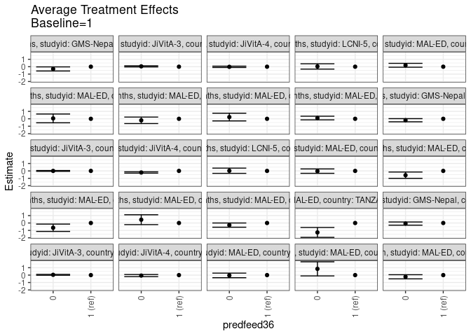

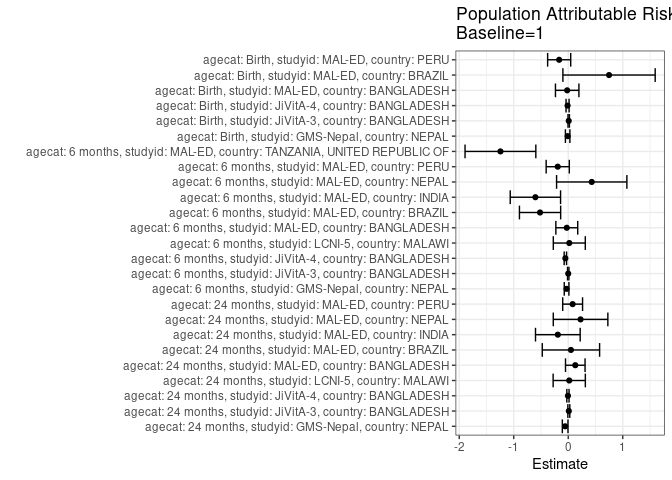

## Results Table

### Parameter: TSM

| agecat | studyid | country | intervention_level | baseline_level | estimate | ci_lower | ci_upper |
| --- | --- | --- | --- | --- | --- | --- | --- |
| Birth | GMS-Nepal | NEPAL | 1 | NA | -1.0977118 | -1.2063967 | -0.9890268 |
| Birth | GMS-Nepal | NEPAL | 0 | NA | -1.1736233 | -1.3713722 | -0.9758744 |
| Birth | JiVitA-3 | BANGLADESH | 1 | NA | -0.7980360 | -0.8249890 | -0.7710829 |
| Birth | JiVitA-3 | BANGLADESH | 0 | NA | -0.7575818 | -0.8100294 | -0.7051343 |
| Birth | JiVitA-4 | BANGLADESH | 1 | NA | -0.6894599 | -0.7453405 | -0.6335792 |
| Birth | JiVitA-4 | BANGLADESH | 0 | NA | -0.7550154 | -0.8917957 | -0.6182351 |
| Birth | MAL-ED | BANGLADESH | 1 | NA | -0.9286430 | -1.1687274 | -0.6885585 |
| Birth | MAL-ED | BANGLADESH | 0 | NA | -0.9707160 | -1.1601082 | -0.7813239 |
| Birth | MAL-ED | BRAZIL | 1 | NA | -0.3457143 | -1.2397629 | 0.5483343 |
| Birth | MAL-ED | BRAZIL | 0 | NA | 0.4981818 | 0.1725808 | 0.8237829 |
| Birth | MAL-ED | PERU | 1 | NA | 0.1206656 | -0.1178763 | 0.3592075 |
| Birth | MAL-ED | PERU | 0 | NA | -0.1046840 | -0.2513369 | 0.0419689 |
| 6 months | GMS-Nepal | NEPAL | 1 | NA | -0.5696402 | -0.6704279 | -0.4688524 |
| 6 months | GMS-Nepal | NEPAL | 0 | NA | -0.7601949 | -0.9484855 | -0.5719042 |
| 6 months | JiVitA-3 | BANGLADESH | 1 | NA | -0.5993867 | -0.6285217 | -0.5702516 |
| 6 months | JiVitA-3 | BANGLADESH | 0 | NA | -0.6019031 | -0.6505456 | -0.5532606 |
| 6 months | JiVitA-4 | BANGLADESH | 1 | NA | -0.3431206 | -0.3888901 | -0.2973511 |
| 6 months | JiVitA-4 | BANGLADESH | 0 | NA | -0.5569164 | -0.6370864 | -0.4767465 |
| 6 months | LCNI-5 | MALAWI | 1 | NA | 0.3730856 | 0.0426920 | 0.7034793 |
| 6 months | LCNI-5 | MALAWI | 0 | NA | 0.3955160 | 0.2689415 | 0.5220906 |
| 6 months | MAL-ED | BANGLADESH | 1 | NA | -0.1086588 | -0.3479892 | 0.1306716 |
| 6 months | MAL-ED | BANGLADESH | 0 | NA | -0.1394867 | -0.3022060 | 0.0232326 |
| 6 months | MAL-ED | BRAZIL | 1 | NA | 1.4894121 | 1.0999281 | 1.8788960 |
| 6 months | MAL-ED | BRAZIL | 0 | NA | 0.9081506 | 0.7308116 | 1.0854896 |
| 6 months | MAL-ED | INDIA | 1 | NA | -0.1135014 | -0.5900503 | 0.3630476 |
| 6 months | MAL-ED | INDIA | 0 | NA | -0.7550620 | -0.8864955 | -0.6236285 |
| 6 months | MAL-ED | NEPAL | 1 | NA | -0.3168750 | -0.9708901 | 0.3371401 |
| 6 months | MAL-ED | NEPAL | 0 | NA | 0.1292144 | -0.0046984 | 0.2631272 |
| 6 months | MAL-ED | PERU | 1 | NA | 1.2440313 | 0.9980721 | 1.4899906 |
| 6 months | MAL-ED | PERU | 0 | NA | 0.9598323 | 0.8183103 | 1.1013542 |
| 6 months | MAL-ED | TANZANIA, UNITED REPUBLIC OF | 1 | NA | 1.7950000 | 1.1425391 | 2.4474609 |
| 6 months | MAL-ED | TANZANIA, UNITED REPUBLIC OF | 0 | NA | 0.5246709 | 0.3926689 | 0.6566728 |
| 24 months | GMS-Nepal | NEPAL | 1 | NA | -1.0670503 | -1.1657820 | -0.9683186 |
| 24 months | GMS-Nepal | NEPAL | 0 | NA | -1.3695224 | -1.6271346 | -1.1119102 |
| 24 months | JiVitA-3 | BANGLADESH | 1 | NA | -1.3458190 | -1.3844030 | -1.3072351 |
| 24 months | JiVitA-3 | BANGLADESH | 0 | NA | -1.2997926 | -1.3659735 | -1.2336116 |
| 24 months | JiVitA-4 | BANGLADESH | 1 | NA | -1.2288397 | -1.2711852 | -1.1864941 |
| 24 months | JiVitA-4 | BANGLADESH | 0 | NA | -1.2456433 | -1.3264866 | -1.1647999 |
| 24 months | LCNI-5 | MALAWI | 1 | NA | -0.0954109 | -0.4151119 | 0.2242901 |
| 24 months | LCNI-5 | MALAWI | 0 | NA | -0.0592991 | -0.2209866 | 0.1023883 |
| 24 months | MAL-ED | BANGLADESH | 1 | NA | -0.9484702 | -1.1503072 | -0.7466332 |
| 24 months | MAL-ED | BANGLADESH | 0 | NA | -0.7570677 | -0.9127507 | -0.6013848 |
| 24 months | MAL-ED | BRAZIL | 1 | NA | 0.4131566 | -0.1350493 | 0.9613624 |
| 24 months | MAL-ED | BRAZIL | 0 | NA | 0.4682120 | 0.2466732 | 0.6897508 |
| 24 months | MAL-ED | INDIA | 1 | NA | -0.7672612 | -1.1877226 | -0.3467997 |
| 24 months | MAL-ED | INDIA | 0 | NA | -0.9723891 | -1.0949606 | -0.8498177 |
| 24 months | MAL-ED | NEPAL | 1 | NA | -0.5987500 | -1.1044659 | -0.0930341 |
| 24 months | MAL-ED | NEPAL | 0 | NA | -0.3643379 | -0.4810145 | -0.2476613 |
| 24 months | MAL-ED | PERU | 1 | NA | 0.0307594 | -0.1611174 | 0.2226362 |
| 24 months | MAL-ED | PERU | 0 | NA | 0.1329676 | -0.0197456 | 0.2856808 |

### Parameter: E(Y)

| agecat | studyid | country | intervention_level | baseline_level | estimate | ci_lower | ci_upper |
| --- | --- | --- | --- | --- | --- | --- | --- |
| Birth | GMS-Nepal | NEPAL | NA | NA | -1.1085743 | -1.2077878 | -1.0093609 |
| Birth | JiVitA-3 | BANGLADESH | NA | NA | -0.7892308 | -0.8133344 | -0.7651272 |
| Birth | JiVitA-4 | BANGLADESH | NA | NA | -0.7018985 | -0.7560164 | -0.6477806 |
| Birth | MAL-ED | BANGLADESH | NA | NA | -0.9480769 | -1.0934921 | -0.8026617 |
| Birth | MAL-ED | BRAZIL | NA | NA | 0.4029032 | 0.0896793 | 0.7161272 |
| Birth | MAL-ED | PERU | NA | NA | -0.0458257 | -0.1696487 | 0.0779973 |
| 6 months | GMS-Nepal | NEPAL | NA | NA | -0.6001075 | -0.6890924 | -0.5111227 |
| 6 months | JiVitA-3 | BANGLADESH | NA | NA | -0.5995202 | -0.6251579 | -0.5738825 |
| 6 months | JiVitA-4 | BANGLADESH | NA | NA | -0.3960017 | -0.4356255 | -0.3563778 |
| 6 months | LCNI-5 | MALAWI | NA | NA | 0.3925000 | 0.2735307 | 0.5114693 |
| 6 months | MAL-ED | BANGLADESH | NA | NA | -0.1354583 | -0.2647102 | -0.0062065 |
| 6 months | MAL-ED | BRAZIL | NA | NA | 0.9720774 | 0.8078144 | 1.1363403 |
| 6 months | MAL-ED | INDIA | NA | NA | -0.7161910 | -0.8437667 | -0.5886153 |
| 6 months | MAL-ED | NEPAL | NA | NA | 0.1140284 | -0.0176364 | 0.2456931 |
| 6 months | MAL-ED | PERU | NA | NA | 1.0511642 | 0.9291821 | 1.1731463 |
| 6 months | MAL-ED | TANZANIA, UNITED REPUBLIC OF | NA | NA | 0.5508093 | 0.4191033 | 0.6825154 |
| 24 months | GMS-Nepal | NEPAL | NA | NA | -1.1236255 | -1.2167712 | -1.0304797 |
| 24 months | JiVitA-3 | BANGLADESH | NA | NA | -1.3352235 | -1.3688736 | -1.3015735 |
| 24 months | JiVitA-4 | BANGLADESH | NA | NA | -1.2344089 | -1.2708428 | -1.1979750 |
| 24 months | LCNI-5 | MALAWI | NA | NA | -0.0770652 | -0.2204213 | 0.0662909 |
| 24 months | MAL-ED | BANGLADESH | NA | NA | -0.8192925 | -0.9412667 | -0.6973182 |
| 24 months | MAL-ED | BRAZIL | NA | NA | 0.4626233 | 0.2567495 | 0.6684971 |
| 24 months | MAL-ED | INDIA | NA | NA | -0.9581250 | -1.0746982 | -0.8415518 |
| 24 months | MAL-ED | NEPAL | NA | NA | -0.3725991 | -0.4867052 | -0.2584930 |
| 24 months | MAL-ED | PERU | NA | NA | 0.1111982 | -0.0118399 | 0.2342362 |

### Parameter: ATE

| agecat | studyid | country | intervention_level | baseline_level | estimate | ci_lower | ci_upper |
| --- | --- | --- | --- | --- | --- | --- | --- |
| Birth | GMS-Nepal | NEPAL | 1 | 1 | 0.0000000 | 0.0000000 | 0.0000000 |
| Birth | GMS-Nepal | NEPAL | 0 | 1 | -0.0759116 | -0.2914873 | 0.1396642 |
| Birth | JiVitA-3 | BANGLADESH | 1 | 1 | 0.0000000 | 0.0000000 | 0.0000000 |
| Birth | JiVitA-3 | BANGLADESH | 0 | 1 | 0.0404541 | -0.0181605 | 0.0990687 |
| Birth | JiVitA-4 | BANGLADESH | 1 | 1 | 0.0000000 | 0.0000000 | 0.0000000 |
| Birth | JiVitA-4 | BANGLADESH | 0 | 1 | -0.0655556 | -0.2092478 | 0.0781367 |
| Birth | MAL-ED | BANGLADESH | 1 | 1 | 0.0000000 | 0.0000000 | 0.0000000 |
| Birth | MAL-ED | BANGLADESH | 0 | 1 | -0.0420731 | -0.3512901 | 0.2671439 |
| Birth | MAL-ED | BRAZIL | 1 | 1 | 0.0000000 | 0.0000000 | 0.0000000 |
| Birth | MAL-ED | BRAZIL | 0 | 1 | 0.8438961 | -0.1075969 | 1.7953891 |
| Birth | MAL-ED | PERU | 1 | 1 | 0.0000000 | 0.0000000 | 0.0000000 |
| Birth | MAL-ED | PERU | 0 | 1 | -0.2253496 | -0.5062481 | 0.0555489 |
| 6 months | GMS-Nepal | NEPAL | 1 | 1 | 0.0000000 | 0.0000000 | 0.0000000 |
| 6 months | GMS-Nepal | NEPAL | 0 | 1 | -0.1905547 | -0.4043523 | 0.0232430 |
| 6 months | JiVitA-3 | BANGLADESH | 1 | 1 | 0.0000000 | 0.0000000 | 0.0000000 |
| 6 months | JiVitA-3 | BANGLADESH | 0 | 1 | -0.0025165 | -0.0577843 | 0.0527513 |
| 6 months | JiVitA-4 | BANGLADESH | 1 | 1 | 0.0000000 | 0.0000000 | 0.0000000 |
| 6 months | JiVitA-4 | BANGLADESH | 0 | 1 | -0.2137959 | -0.3058832 | -0.1217085 |
| 6 months | LCNI-5 | MALAWI | 1 | 1 | 0.0000000 | 0.0000000 | 0.0000000 |
| 6 months | LCNI-5 | MALAWI | 0 | 1 | 0.0224304 | -0.3316005 | 0.3764613 |
| 6 months | MAL-ED | BANGLADESH | 1 | 1 | 0.0000000 | 0.0000000 | 0.0000000 |
| 6 months | MAL-ED | BANGLADESH | 0 | 1 | -0.0308279 | -0.3268593 | 0.2652035 |
| 6 months | MAL-ED | BRAZIL | 1 | 1 | 0.0000000 | 0.0000000 | 0.0000000 |
| 6 months | MAL-ED | BRAZIL | 0 | 1 | -0.5812615 | -1.0072751 | -0.1552478 |
| 6 months | MAL-ED | INDIA | 1 | 1 | 0.0000000 | 0.0000000 | 0.0000000 |
| 6 months | MAL-ED | INDIA | 0 | 1 | -0.6415606 | -1.1363441 | -0.1467771 |
| 6 months | MAL-ED | NEPAL | 1 | 1 | 0.0000000 | 0.0000000 | 0.0000000 |
| 6 months | MAL-ED | NEPAL | 0 | 1 | 0.4460894 | -0.2214946 | 1.1136734 |
| 6 months | MAL-ED | PERU | 1 | 1 | 0.0000000 | 0.0000000 | 0.0000000 |
| 6 months | MAL-ED | PERU | 0 | 1 | -0.2841991 | -0.5691140 | 0.0007159 |
| 6 months | MAL-ED | TANZANIA, UNITED REPUBLIC OF | 1 | 1 | 0.0000000 | 0.0000000 | 0.0000000 |
| 6 months | MAL-ED | TANZANIA, UNITED REPUBLIC OF | 0 | 1 | -1.2703291 | -1.9360090 | -0.6046493 |
| 24 months | GMS-Nepal | NEPAL | 1 | 1 | 0.0000000 | 0.0000000 | 0.0000000 |
| 24 months | GMS-Nepal | NEPAL | 0 | 1 | -0.3024721 | -0.5791623 | -0.0257819 |
| 24 months | JiVitA-3 | BANGLADESH | 1 | 1 | 0.0000000 | 0.0000000 | 0.0000000 |
| 24 months | JiVitA-3 | BANGLADESH | 0 | 1 | 0.0460265 | -0.0298831 | 0.1219361 |
| 24 months | JiVitA-4 | BANGLADESH | 1 | 1 | 0.0000000 | 0.0000000 | 0.0000000 |
| 24 months | JiVitA-4 | BANGLADESH | 0 | 1 | -0.0168036 | -0.1063312 | 0.0727240 |
| 24 months | LCNI-5 | MALAWI | 1 | 1 | 0.0000000 | 0.0000000 | 0.0000000 |
| 24 months | LCNI-5 | MALAWI | 0 | 1 | 0.0361118 | -0.3218832 | 0.3941068 |
| 24 months | MAL-ED | BANGLADESH | 1 | 1 | 0.0000000 | 0.0000000 | 0.0000000 |
| 24 months | MAL-ED | BANGLADESH | 0 | 1 | 0.1914025 | -0.0693868 | 0.4521919 |
| 24 months | MAL-ED | BRAZIL | 1 | 1 | 0.0000000 | 0.0000000 | 0.0000000 |
| 24 months | MAL-ED | BRAZIL | 0 | 1 | 0.0550554 | -0.5371308 | 0.6472416 |
| 24 months | MAL-ED | INDIA | 1 | 1 | 0.0000000 | 0.0000000 | 0.0000000 |
| 24 months | MAL-ED | INDIA | 0 | 1 | -0.2051280 | -0.6433236 | 0.2330677 |
| 24 months | MAL-ED | NEPAL | 1 | 1 | 0.0000000 | 0.0000000 | 0.0000000 |
| 24 months | MAL-ED | NEPAL | 0 | 1 | 0.2344121 | -0.2845889 | 0.7534131 |
| 24 months | MAL-ED | PERU | 1 | 1 | 0.0000000 | 0.0000000 | 0.0000000 |
| 24 months | MAL-ED | PERU | 0 | 1 | 0.1022082 | -0.1439276 | 0.3483441 |

### Parameter: PAR

| agecat | studyid | country | intervention_level | baseline_level | estimate | ci_lower | ci_upper |
| --- | --- | --- | --- | --- | --- | --- | --- |
| Birth | GMS-Nepal | NEPAL | 1 | NA | -0.0108626 | -0.0519586 | 0.0302335 |
| Birth | JiVitA-3 | BANGLADESH | 1 | NA | 0.0088052 | -0.0039256 | 0.0215360 |
| Birth | JiVitA-4 | BANGLADESH | 1 | NA | -0.0124386 | -0.0404624 | 0.0155852 |
| Birth | MAL-ED | BANGLADESH | 1 | NA | -0.0194340 | -0.2346174 | 0.1957495 |
| Birth | MAL-ED | BRAZIL | 1 | NA | 0.7486175 | -0.0981055 | 1.5953405 |
| Birth | MAL-ED | PERU | 1 | NA | -0.1664913 | -0.3782046 | 0.0452220 |
| 6 months | GMS-Nepal | NEPAL | 1 | NA | -0.0304673 | -0.0733588 | 0.0124241 |
| 6 months | JiVitA-3 | BANGLADESH | 1 | NA | -0.0001336 | -0.0128385 | 0.0125714 |
| 6 months | JiVitA-4 | BANGLADESH | 1 | NA | -0.0528811 | -0.0747028 | -0.0310594 |
| 6 months | LCNI-5 | MALAWI | 1 | NA | 0.0194144 | -0.2740837 | 0.3129124 |
| 6 months | MAL-ED | BANGLADESH | 1 | NA | -0.0267996 | -0.2273868 | 0.1737877 |
| 6 months | MAL-ED | BRAZIL | 1 | NA | -0.5173347 | -0.8953751 | -0.1392944 |
| 6 months | MAL-ED | INDIA | 1 | NA | -0.6026896 | -1.0644852 | -0.1408941 |
| 6 months | MAL-ED | NEPAL | 1 | NA | 0.4309034 | -0.2140376 | 1.0758444 |
| 6 months | MAL-ED | PERU | 1 | NA | -0.1928671 | -0.4052232 | 0.0194890 |
| 6 months | MAL-ED | TANZANIA, UNITED REPUBLIC OF | 1 | NA | -1.2441907 | -1.8936261 | -0.5947552 |
| 24 months | GMS-Nepal | NEPAL | 1 | NA | -0.0565751 | -0.1083914 | -0.0047589 |
| 24 months | JiVitA-3 | BANGLADESH | 1 | NA | 0.0105955 | -0.0069958 | 0.0281868 |
| 24 months | JiVitA-4 | BANGLADESH | 1 | NA | -0.0055693 | -0.0260233 | 0.0148848 |
| 24 months | LCNI-5 | MALAWI | 1 | NA | 0.0183457 | -0.2770945 | 0.3137860 |
| 24 months | MAL-ED | BANGLADESH | 1 | NA | 0.1291778 | -0.0501730 | 0.3085286 |
| 24 months | MAL-ED | BRAZIL | 1 | NA | 0.0494667 | -0.4764832 | 0.5754166 |
| 24 months | MAL-ED | INDIA | 1 | NA | -0.1908638 | -0.6006696 | 0.2189419 |
| 24 months | MAL-ED | NEPAL | 1 | NA | 0.2261509 | -0.2745910 | 0.7268928 |
| 24 months | MAL-ED | PERU | 1 | NA | 0.0804388 | -0.1017917 | 0.2626693 |